# Project: Movies Data Analysis

- Introduction
- Data Wrangling
- Exploratory Data Analysis
- Conclusions

## Introduction

How can we measure a success of a movie ? -It could be by different parameters like:

- The vote rate for the movie if it's highly rated like (8 or 9) in scale of 10 or very low rate like (4 or 5).
- The budget of the movie, mostly the movie with high budget has a bigger probability to succeed.
- The revenue of the movie ofcourse is a good indicator for the suceess of the movie.
- The popularity of the movie and how much propaganda it has.
- The genres or the type of the movie, maybe Action movies have the biggest revenues.
- The cast, the crew or the production companies could give us an impact about success this movie.

So I'm going to digging into those questions, with data on the vote rate, cast, crew, budget, and revenues of several films, and analyze it .....................

other questions:-

- Which genres are most popular from year to year?
- What kinds of properties are associated with the movie that has the highest revenue?

```python
# import needed packages
import pandas as pd
import numpy as np
import seaborn as sns
import matplotlib.pyplot as plt
%matplotlib inline
```

## Data Wrangling

### General Properties

```python
# Read the data
Movies_Analysis = pd.read_csv("tmdb-movies.csv")
Movies_Analysis.head(2)
```

|  | id | imdb_id | popularity | budget | revenue | original_title | cast | homepage | director | tagline | ... | overview | runtime | genres | production_companies | release_date | vote_count | vote_average | release_year | budget_adj | revenue_adj |
| --- | --- | --- | --- | --- | --- | --- | --- | --- | --- | --- | --- | --- | --- | --- | --- | --- | --- | --- | --- | --- | --- |
| 0 | 135397 | tt0369610 | 32.985763 | 150000000 | 1513528810 | Jurassic World | Chris Pratt\|Bryce Dallas Howard\|Irrfan Khan\|Vi... | http://www.jurassicworld.com/ | Colin Trevorrow | The park is open. | ... | Twenty-two years after the events of Jurassic ... | 124 | Action\|Adventure\|Science Fiction\|Thriller | Universal Studios\|Amblin Entertainment\|Legenda... | 6/9/15 | 5562 | 6.5 | 2015 | 1.379999e+08 | 1.392446e+09 |
| 1 | 76341 | tt1392190 | 28.419936 | 150000000 | 378436354 | Mad Max: Fury Road | Tom Hardy\|Charlize Theron\|Hugh Keays-Byrne\|Nic... | http://www.madmaxmovie.com/ | George Miller | What a Lovely Day. | ... | An apocalyptic story set in the furthest reach... | 120 | Action\|Adventure\|Science Fiction\|Thriller | Village Roadshow Pictures\|Kennedy Miller Produ... | 5/13/15 | 6185 | 7.1 | 2015 | 1.379999e+08 | 3.481613e+08 |

2 rows × 21 columns

```python
Movies_Analysis.shape
```

```
(10866, 21)
```

```python
# summary statistics
Movies_Analysis.describe()
```

|  | id | popularity | budget | revenue | runtime | vote_count | vote_average | release_year | budget_adj | revenue_adj |
| --- | --- | --- | --- | --- | --- | --- | --- | --- | --- | --- |
| count | 10866.000000 | 10866.000000 | 1.086600e+04 | 1.086600e+04 | 10866.000000 | 10866.000000 | 10866.000000 | 10866.000000 | 1.086600e+04 | 1.086600e+04 |
| mean | 66064.177434 | 0.646441 | 1.462570e+07 | 3.982332e+07 | 102.070863 | 217.389748 | 5.974922 | 2001.322658 | 1.755104e+07 | 5.136436e+07 |
| std | 92130.136561 | 1.000185 | 3.091321e+07 | 1.170035e+08 | 31.381405 | 575.619058 | 0.935142 | 12.812941 | 3.430616e+07 | 1.446325e+08 |
| min | 5.000000 | 0.000065 | 0.000000e+00 | 0.000000e+00 | 0.000000 | 10.000000 | 1.500000 | 1960.000000 | 0.000000e+00 | 0.000000e+00 |
| 25% | 10596.250000 | 0.207583 | 0.000000e+00 | 0.000000e+00 | 90.000000 | 17.000000 | 5.400000 | 1995.000000 | 0.000000e+00 | 0.000000e+00 |
| 50% | 20669.000000 | 0.383856 | 0.000000e+00 | 0.000000e+00 | 99.000000 | 38.000000 | 6.000000 | 2006.000000 | 0.000000e+00 | 0.000000e+00 |
| 75% | 75610.000000 | 0.713817 | 1.500000e+07 | 2.400000e+07 | 111.000000 | 145.750000 | 6.600000 | 2011.000000 | 2.085325e+07 | 3.369710e+07 |
| max | 417859.000000 | 32.985763 | 4.250000e+08 | 2.781506e+09 | 900.000000 | 9767.000000 | 9.200000 | 2015.000000 | 4.250000e+08 | 2.827124e+09 |

```python
# more information about the data
Movies_Analysis.info()
```

```
<class 'pandas.core.frame.DataFrame'>
RangeIndex: 10866 entries, 0 to 10865
Data columns (total 21 columns):
id                      10866 non-null int64
imdb_id                 10856 non-null object
popularity              10866 non-null float64
budget                  10866 non-null int64
revenue                 10866 non-null int64
original_title          10866 non-null object
cast                    10790 non-null object
homepage                2936 non-null object
director                10822 non-null object
tagline                 8042 non-null object
keywords                9373 non-null object
overview                10862 non-null object
runtime                 10866 non-null int64
genres                  10843 non-null object
production_companies    9836 non-null object
release_date            10866 non-null object
vote_count              10866 non-null int64
vote_average            10866 non-null float64
release_year            10866 non-null int64
budget_adj              10866 non-null float64
revenue_adj             10866 non-null float64
dtypes: float64(4), int64(6), object(11)
memory usage: 1.7+ MB
```

```python
Movies_Analysis.nunique()
```

```
id                      10865
imdb_id                 10855
popularity              10814
budget                    557
revenue                  4702
original_title          10571
cast                    10719
homepage                 2896
director                 5067
tagline                  7997
keywords                 8804
overview                10847
runtime                   247
genres                   2039
production_companies     7445
release_date             5909
vote_count               1289
vote_average               72
release_year               56
budget_adj               2614
revenue_adj              4840
dtype: int64
```

```python
# number of duplicated values
Movies_Analysis.duplicated().sum()
```

```
1
```

```python
# data types..
Movies_Analysis.dtypes
```

```
id                        int64
imdb_id                  object
popularity              float64
budget                    int64
revenue                   int64
original_title           object
cast                     object
homepage                 object
director                 object
tagline                  object
keywords                 object
overview                 object
runtime                   int64
genres                   object
production_companies     object
release_date             object
vote_count                int64
vote_average            float64
release_year              int64
budget_adj              float64
revenue_adj             float64
dtype: object
```

### Data Cleaning

```python
# At first i will copy the original data and work on the copied one.
movies = Movies_Analysis.copy()
movies.head(2)
```

|  | id | imdb_id | popularity | budget | revenue | original_title | cast | homepage | director | tagline | ... | overview | runtime | genres | production_companies | release_date | vote_count | vote_average | release_year | budget_adj | revenue_adj |
| --- | --- | --- | --- | --- | --- | --- | --- | --- | --- | --- | --- | --- | --- | --- | --- | --- | --- | --- | --- | --- | --- |
| 0 | 135397 | tt0369610 | 32.985763 | 150000000 | 1513528810 | Jurassic World | Chris Pratt\|Bryce Dallas Howard\|Irrfan Khan\|Vi... | http://www.jurassicworld.com/ | Colin Trevorrow | The park is open. | ... | Twenty-two years after the events of Jurassic ... | 124 | Action\|Adventure\|Science Fiction\|Thriller | Universal Studios\|Amblin Entertainment\|Legenda... | 6/9/15 | 5562 | 6.5 | 2015 | 1.379999e+08 | 1.392446e+09 |
| 1 | 76341 | tt1392190 | 28.419936 | 150000000 | 378436354 | Mad Max: Fury Road | Tom Hardy\|Charlize Theron\|Hugh Keays-Byrne\|Nic... | http://www.madmaxmovie.com/ | George Miller | What a Lovely Day. | ... | An apocalyptic story set in the furthest reach... | 120 | Action\|Adventure\|Science Fiction\|Thriller | Village Roadshow Pictures\|Kennedy Miller Produ... | 5/13/15 | 6185 | 7.1 | 2015 | 1.379999e+08 | 3.481613e+08 |

2 rows × 21 columns

```python
# determine number of null values.
movies.isnull().sum()
```

```
id                         0
imdb_id                   10
popularity                 0
budget                     0
revenue                    0
original_title             0
cast                      76
homepage                7930
director                  44
tagline                 2824
keywords                1493
overview                   4
runtime                    0
genres                    23
production_companies    1030
release_date               0
vote_count                 0
vote_average               0
release_year               0
budget_adj                 0
revenue_adj                0
dtype: int64
```

### Drop Extraneous Columns

```python
# drop columns from movies dataset
movies.drop(['id', 'imdb_id', 'homepage', 'tagline', 'keywords', 'overview' ], axis=1, inplace=True)

# confirm changes
movies.head(1)
```

|  | popularity | budget | revenue | original_title | cast | director | runtime | genres | production_companies | release_date | vote_count | vote_average | release_year | budget_adj | revenue_adj |
| --- | --- | --- | --- | --- | --- | --- | --- | --- | --- | --- | --- | --- | --- | --- | --- |
| 0 | 32.985763 | 150000000 | 1513528810 | Jurassic World | Chris Pratt\|Bryce Dallas Howard\|Irrfan Khan\|Vi... | Colin Trevorrow | 124 | Action\|Adventure\|Science Fiction\|Thriller | Universal Studios\|Amblin Entertainment\|Legenda... | 6/9/15 | 5562 | 6.5 | 2015 | 1.379999e+08 | 1.392446e+09 |

```python
# view dimensions of dataset
movies.shape
```

```
(10866, 15)
```

## Drop Rows with Missing Values

```python
# view missing value count for the movies dataset
movies.isnull().sum()
```

```
popularity                 0
budget                     0
revenue                    0
original_title             0
cast                      76
director                  44
runtime                    0
genres                    23
production_companies    1030
release_date               0
vote_count                 0
vote_average               0
release_year               0
budget_adj                 0
revenue_adj                0
dtype: int64
```

```python
# drop rows with any null values in the dataset.
movies.dropna(inplace=True)
```

```python
# checks if any of columns in the dataset have null values.
movies.isnull().sum().any()
```

```
False
```

```python
# view dimensions of dataset
movies.shape
```

```
(9773, 15)
```

```python
# print number of duplicates in the movies dataset
print(movies.duplicated().sum())
```

```
1
```

```python
# drop duplicates in the dataset
movies.drop_duplicates(inplace=True)
```

```python
# print number of duplicates in the movies dataset
print(movies.duplicated().sum())
```

```
0
```

```python
movies.info()
```

```
<class 'pandas.core.frame.DataFrame'>
Int64Index: 9772 entries, 0 to 10865
Data columns (total 15 columns):
popularity              9772 non-null float64
budget                  9772 non-null int64
revenue                 9772 non-null int64
original_title          9772 non-null object
cast                    9772 non-null object
director                9772 non-null object
runtime                 9772 non-null int64
genres                  9772 non-null object
production_companies    9772 non-null object
release_date            9772 non-null object
vote_count              9772 non-null int64
vote_average            9772 non-null float64
release_year            9772 non-null int64
budget_adj              9772 non-null float64
revenue_adj             9772 non-null float64
dtypes: float64(4), int64(5), object(6)
memory usage: 1.2+ MB
```

### Draw Histogram for the movies dataset

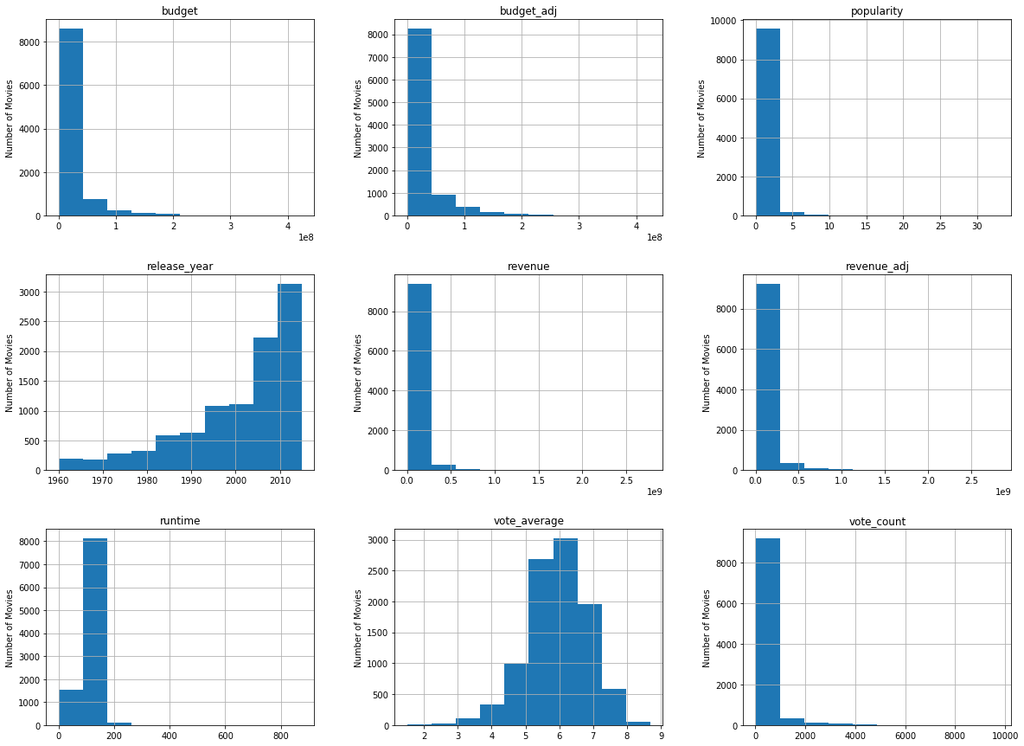

```python
axarr = movies.hist(figsize=(20, 15));
for ax in axarr.flatten():
        ax.set_ylabel("Number of Movies")
```

```python
movies['production_companies'].value_counts()
```

```
Paramount Pictures                                                                                                                  156
Universal Pictures                                                                                                                  133
Warner Bros.                                                                                                                         84
Walt Disney Pictures                                                                                                                 75
Columbia Pictures                                                                                                                    72
Metro-Goldwyn-Mayer (MGM)                                                                                                            72
New Line Cinema                                                                                                                      61
Touchstone Pictures                                                                                                                  51
20th Century Fox                                                                                                                     50
Twentieth Century Fox Film Corporation                                                                                               49
TriStar Pictures                                                                                                                     45
Orion Pictures                                                                                                                       42
Miramax Films                                                                                                                        32
Columbia Pictures Corporation                                                                                                        31
DreamWorks Animation                                                                                                                 31
Walt Disney Productions                                                                                                              29
Dimension Films                                                                                                                      28
United Artists                                                                                                                       23
Pixar Animation Studios                                                                                                              23
Imagine Entertainment|Universal Pictures                                                                                             22
Marvel Studios                                                                                                                       22
The Asylum                                                                                                                           21
Lions Gate Films                                                                                                                     21
New World Pictures                                                                                                                   17
Walt Disney Pictures|Pixar Animation Studios                                                                                         17
American International Pictures (AIP)                                                                                                14
Disney Channel                                                                                                                       14
Hammer Film Productions                                                                                                              13
Hollywood Pictures                                                                                                                   12
Walt Disney Pictures|Walt Disney Feature Animation                                                                                   12
                                                                                                                                   ...
Spyglass Entertainment|Touchstone Pictures|Birnbaum / Barber Productions|Jackie Chan Films Limited|All Knight Productions             1
Fox 2000 Pictures|Lynda Obst Productions                                                                                              1
Miramax Films|Imagine Entertainment|Universal Pictures|Parkway Pictures (I)|Touchstone Pictures                                       1
New South Wales Film Corp.|Springvale Productions                                                                                     1
Alquimia Cinema|Arcane Pictures                                                                                                       1
Universal Pictures|Mosaic Media Group|Wild West Picture Show Productions                                                              1
PF Pictures|Naked City Films                                                                                                          1
Maran Film|Bavaria Film|Kettledrum Productions                                                                                        1
Metro-Goldwyn-Mayer (MGM)|McElroy & McElroy                                                                                           1
The Hatchery|Sony Pictures Television|Magna Global Entertainment|Johnson & Johnson Spotlight Presentations|Thomas Carter Company      1
```

[output cut: 21 more lines]

```python
movies['genres'].value_counts()
```

```
Drama                                                  638
Comedy                                                 615
Drama|Romance                                          272
Comedy|Drama                                           255
Comedy|Romance                                         248
Horror|Thriller                                        243
Horror                                                 231
Comedy|Drama|Romance                                   203
Documentary                                            185
Drama|Thriller                                         128
Comedy|Family                                           97
Action|Thriller                                         92
Thriller                                                88
Drama|Comedy                                            85
Crime|Drama|Thriller                                    76
Animation|Family                                        71
Crime|Drama                                             69
Comedy|Horror                                           67
Drama|Comedy|Romance                                    58
Action                                                  57
Action|Comedy                                           55
Drama|History                                           54
Drama|Horror|Thriller                                   53
Action|Crime|Drama|Thriller                             53
Action|Crime|Thriller                                   51
Horror|Mystery|Thriller                                 51
Comedy|Crime                                            48
Horror|Science Fiction                                  46
Drama|Crime                                             44
Thriller|Horror                                         44
                                                      ...
Fantasy|Science Fiction|Animation|Action|Adventure       1
Adventure|Family|Animation|Action|Comedy                 1
Comedy|Drama|Family|Fantasy|Foreign                      1
Fantasy|Animation|Drama|Family                           1
Comedy|Drama|Crime|Thriller                              1
Animation|Science Fiction|Fantasy|Adventure              1
Adventure|Fantasy|Animation|Action|Thriller              1
Music|Drama|Crime                                        1
Comedy|Music|Romance|Drama                               1
Animation|Music                                          1
Animation|Action|Family|Science Fiction                  1
Crime|Fantasy|Science Fiction|Thriller                   1
Action|Horror|Mystery|Thriller                           1
Adventure|Drama|Action|Romance|Family                    1
Comedy|Family|Adventure|Romance                          1
Animation|Fantasy|Comedy|Science Fiction                 1
Horror|Science Fiction|Crime                             1
Drama|Adventure|Science Fiction                          1
Crime|Horror|Action|Thriller                             1
War|Action|Adventure|Drama                               1
Science Fiction|Mystery|Horror|Thriller                  1
Drama|Mystery|Thriller|Horror                            1
Adventure|Fantasy|Horror|Action|Thriller                 1
Drama|History|Crime                                      1
Horror|Mystery|Crime                                     1
Crime|Drama|Horror|Mystery|Science Fiction               1
Thriller|Animation|Action|Science Fiction|Adventure      1
Drama|Family|Comedy|TV Movie                             1
Comedy|Science Fiction|Family                            1
Comedy|Fantasy|Thriller                                  1
Name: genres, Length: 1916, dtype: int64
```

### First, I chose The dependent variable to be the vote average and we could have many independent variables like:

- Budget
- Popularity
- Revenue
- Genres

```python
masterpiece_movie = movies.query('vote_average >= ' + str(8.5) )
remarkable_movie  = movies.query('vote_average >= ' + str(7.0) )
ordinary_movie    = movies.query('vote_average <= ' + str(7.0) )
```

```python
masterpiece_movie["vote_average"].mean()
```

```
8.55
```

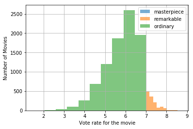

```python
masterpiece_movie["vote_average"].hist( alpha = 0.6, bins=10, label = "masterpiece" )
remarkable_movie["vote_average"].hist( alpha = 0.6, bins=10, label = "remarkable" )
ordinary_movie["vote_average"].hist( alpha = 0.6, bins=10, label = "ordinary" )
plt.legend()
plt.xlabel("Vote rate for the movie")
plt.ylabel("Number of Movies");
```

## From this graph we note that most of the movies in range of 5 to 7 (ordinary movie) class.

```python
masterpiece_movie.groupby('vote_average').mean()
```

| vote_average | popularity | budget | revenue | runtime | vote_count | release_year | budget_adj | revenue_adj |
| --- | --- | --- | --- | --- | --- | --- | --- | --- |
| 8.5 | 0.273046 | 0.0 | 0.0 | 147.666667 | 28.333333 | 1995.666667 | 0.0 | 0.0 |
| 8.7 | 0.212010 | 0.0 | 0.0 | 145.000000 | 23.000000 | 2006.000000 | 0.0 | 0.0 |

```python
remarkable_movie.groupby('vote_average').mean()#.plot(kind='bar')
```

| vote_average | popularity | budget | revenue | runtime | vote_count | release_year | budget_adj | revenue_adj |
| --- | --- | --- | --- | --- | --- | --- | --- | --- |
| 7.0 | 0.832628 | 1.555241e+07 | 6.219759e+07 | 106.152610 | 383.650602 | 1996.212851 | 1.939556e+07 | 9.745772e+07 |
| 7.1 | 1.106870 | 1.731715e+07 | 7.200126e+07 | 107.093617 | 476.246809 | 1999.357447 | 2.055861e+07 | 8.674892e+07 |
| 7.2 | 0.993841 | 1.458391e+07 | 6.776929e+07 | 108.130208 | 458.343750 | 1998.296875 | 2.018982e+07 | 1.134879e+08 |
| 7.3 | 1.246703 | 2.338038e+07 | 1.050449e+08 | 110.343373 | 654.662651 | 1998.951807 | 2.732723e+07 | 1.369457e+08 |
| 7.4 | 1.126511 | 2.110220e+07 | 1.046813e+08 | 108.063063 | 593.459459 | 1999.477477 | 2.506960e+07 | 1.246231e+08 |
| 7.5 | 1.272380 | 2.077490e+07 | 1.242077e+08 | 110.113402 | 702.463918 | 1998.195876 | 2.690715e+07 | 1.623403e+08 |
| 7.6 | 1.909433 | 2.589106e+07 | 1.065157e+08 | 107.698630 | 1029.931507 | 2002.328767 | 2.723625e+07 | 1.203124e+08 |
| 7.7 | 1.766669 | 2.427706e+07 | 1.330676e+08 | 111.333333 | 1154.843137 | 2001.352941 | 2.968482e+07 | 1.822500e+08 |
| 7.8 | 1.823960 | 1.827054e+07 | 1.033571e+08 | 119.820000 | 1088.600000 | 2005.780000 | 2.231177e+07 | 1.407421e+08 |
| 7.9 | 2.559733 | 2.265722e+07 | 1.582384e+08 | 104.583333 | 1542.888889 | 2003.277778 | 2.681350e+07 | 2.371475e+08 |
| 8.0 | 2.454612 | 1.692356e+07 | 9.827158e+07 | 121.100000 | 1081.000000 | 2001.933333 | 1.888693e+07 | 1.466827e+08 |
| 8.1 | 3.493581 | 3.418182e+07 | 2.149816e+08 | 147.818182 | 2680.454545 | 2002.000000 | 4.384508e+07 | 2.868483e+08 |
| 8.2 | 1.310497 | 8.250000e+05 | 3.498273e+06 | 77.500000 | 611.750000 | 2005.750000 | 7.599001e+05 | 3.222228e+06 |
| 8.3 | 0.908553 | 8.571429e+05 | 3.500949e+07 | 185.000000 | 592.428571 | 2000.000000 | 4.469624e+06 | 1.825591e+08 |
| 8.4 | 1.890747 | 7.550000e+06 | 8.330098e+06 | 147.250000 | 1465.000000 | 2001.500000 | 1.076019e+07 | 1.303611e+07 |
| 8.5 | 0.273046 | 0.000000e+00 | 0.000000e+00 | 147.666667 | 28.333333 | 1995.666667 | 0.000000e+00 | 0.000000e+00 |
| 8.7 | 0.212010 | 0.000000e+00 | 0.000000e+00 | 145.000000 | 23.000000 | 2006.000000 | 0.000000e+00 | 0.000000e+00 |

```python
ordinary_movie.groupby('vote_average').mean()
```

| vote_average | popularity | budget | revenue | runtime | vote_count | release_year | budget_adj | revenue_adj |
| --- | --- | --- | --- | --- | --- | --- | --- | --- |
| 1.5 | 0.078520 | 9.500000e+03 | 0.000000e+00 | 80.000000 | 12.500000 | 1986.500000 | 6.382114e+04 | 0.000000e+00 |
| 2.0 | 0.079281 | 0.000000e+00 | 0.000000e+00 | 75.000000 | 13.000000 | 2012.000000 | 0.000000e+00 | 0.000000e+00 |
| 2.1 | 0.158833 | 0.000000e+00 | 4.554661e+06 | 87.500000 | 14.000000 | 2007.500000 | 0.000000e+00 | 5.258107e+06 |
| 2.2 | 0.051765 | 2.166667e+07 | 2.456867e+04 | 87.333333 | 14.333333 | 2012.333333 | 2.057779e+07 | 2.333395e+04 |
| 2.3 | 0.209701 | 0.000000e+00 | 0.000000e+00 | 86.000000 | 12.000000 | 2004.000000 | 0.000000e+00 | 0.000000e+00 |
| 2.4 | 0.234992 | 2.333333e+05 | 0.000000e+00 | 88.500000 | 13.500000 | 2013.000000 | 2.149212e+05 | 0.000000e+00 |
| 2.5 | 0.280798 | 0.000000e+00 | 0.000000e+00 | 89.000000 | 25.500000 | 2007.500000 | 0.000000e+00 | 0.000000e+00 |
| 2.6 | 0.473599 | 0.000000e+00 | 0.000000e+00 | 80.000000 | 18.000000 | 2013.000000 | 0.000000e+00 | 0.000000e+00 |
| 2.7 | 0.246462 | 0.000000e+00 | 0.000000e+00 | 87.000000 | 21.000000 | 1996.500000 | 0.000000e+00 | 0.000000e+00 |
| 2.8 | 0.140058 | 2.360000e+06 | 0.000000e+00 | 86.600000 | 15.400000 | 2009.800000 | 2.552739e+06 | 0.000000e+00 |
| 2.9 | 0.254027 | 7.000000e+04 | 0.000000e+00 | 91.200000 | 22.200000 | 2000.000000 | 6.785786e+04 | 0.000000e+00 |
| 3.0 | 0.154577 | 8.833333e+05 | 0.000000e+00 | 96.333333 | 15.666667 | 2000.500000 | 1.119467e+06 | 0.000000e+00 |
| 3.1 | 0.318573 | 1.350000e+07 | 1.067619e+06 | 92.300000 | 41.200000 | 2003.400000 | 1.367724e+07 | 2.337352e+06 |
| 3.2 | 0.333257 | 7.666667e+05 | 0.000000e+00 | 88.833333 | 19.000000 | 2003.000000 | 7.764698e+05 | 0.000000e+00 |
| 3.3 | 0.363937 | 4.024546e+06 | 1.610394e+06 | 88.727273 | 22.181818 | 2010.272727 | 4.428776e+06 | 1.843680e+06 |
| 3.4 | 0.266744 | 3.347222e+06 | 6.173588e+06 | 84.277778 | 27.333333 | 2005.777778 | 3.560247e+06 | 6.799994e+06 |
| 3.5 | 0.294672 | 5.709260e+06 | 5.690731e+05 | 90.481481 | 20.851852 | 2007.000000 | 6.785164e+06 | 6.479466e+05 |
| 3.6 | 0.355204 | 4.434783e+06 | 3.412309e+06 | 93.043478 | 20.217391 | 2006.478261 | 4.662801e+06 | 6.724016e+06 |
| 3.7 | 0.294698 | 3.916667e+06 | 2.906007e+06 | 96.444444 | 23.000000 | 2007.500000 | 5.765657e+06 | 5.557392e+06 |
| 3.8 | 0.371919 | 6.181078e+06 | 3.667539e+06 | 97.058824 | 29.058824 | 2006.147059 | 7.742125e+06 | 5.167053e+06 |
| 3.9 | 0.414928 | 6.661111e+06 | 4.846278e+06 | 94.250000 | 62.500000 | 2005.027778 | 7.806903e+06 | 5.741703e+06 |
| 4.0 | 0.331485 | 8.006000e+06 | 4.762975e+06 | 92.936170 | 28.297872 | 2005.085106 | 1.047526e+07 | 5.788001e+06 |
| 4.1 | 0.343938 | 4.816980e+06 | 2.451454e+06 | 92.446429 | 30.392857 | 2007.535714 | 6.062768e+06 | 3.611272e+06 |
| 4.2 | 0.321631 | 4.764468e+06 | 5.287459e+06 | 93.028986 | 39.536232 | 2007.623188 | 5.591791e+06 | 7.033856e+06 |
| 4.3 | 0.415106 | 8.468841e+06 | 5.383626e+06 | 91.710145 | 47.318841 | 2002.884058 | 1.061184e+07 | 6.897004e+06 |
| 4.4 | 0.440293 | 1.171942e+07 | 1.032389e+07 | 95.628866 | 68.618557 | 2004.226804 | 1.404589e+07 | 1.319409e+07 |
| 4.5 | 0.343661 | 7.588298e+06 | 7.262675e+06 | 94.163462 | 37.990385 | 2003.326923 | 8.912247e+06 | 8.258503e+06 |
| 4.6 | 0.331268 | 8.695688e+06 | 9.340493e+06 | 95.972477 | 39.761468 | 2003.385321 | 1.088639e+07 | 1.139154e+07 |
| 4.7 | 0.370544 | 7.388060e+06 | 9.458223e+06 | 93.492537 | 55.738806 | 2004.686567 | 9.196425e+06 | 1.196858e+07 |
| 4.8 | 0.389016 | 1.055441e+07 | 1.087780e+07 | 94.758824 | 50.264706 | 2002.800000 | 1.293864e+07 | 1.447703e+07 |
| 4.9 | 0.424606 | 1.043632e+07 | 1.036779e+07 | 96.861878 | 64.596685 | 2004.027624 | 1.206065e+07 | 1.252930e+07 |
| 5.0 | 0.447507 | 9.946494e+06 | 1.348709e+07 | 95.828283 | 66.227273 | 2003.520202 | 1.158254e+07 | 1.681302e+07 |
| 5.1 | 0.499403 | 1.387341e+07 | 2.067377e+07 | 96.724444 | 90.617778 | 2003.271111 | 1.615174e+07 | 2.393151e+07 |
| 5.2 | 0.526340 | 1.630922e+07 | 2.308165e+07 | 98.007547 | 116.309434 | 2003.475472 | 1.906075e+07 | 2.698549e+07 |
| 5.3 | 0.536327 | 1.555646e+07 | 2.331084e+07 | 97.942943 | 100.294294 | 2002.810811 | 1.849618e+07 | 2.695454e+07 |
| 5.4 | 0.527451 | 1.518632e+07 | 2.228465e+07 | 97.164516 | 109.648387 | 2002.738710 | 1.809202e+07 | 2.670509e+07 |
| 5.5 | 0.530390 | 1.654931e+07 | 3.413142e+07 | 100.290230 | 130.146552 | 2002.166667 | 1.865363e+07 | 4.100573e+07 |
| 5.6 | 0.565060 | 1.776437e+07 | 3.978472e+07 | 99.818421 | 155.807895 | 2001.855263 | 2.070825e+07 | 4.643979e+07 |
| 5.7 | 0.537769 | 1.407981e+07 | 3.138724e+07 | 100.431217 | 132.476190 | 2001.063492 | 1.679859e+07 | 4.005801e+07 |
| 5.8 | 0.617468 | 1.830079e+07 | 4.030061e+07 | 102.480984 | 158.125280 | 2001.080537 | 2.176236e+07 | 4.742809e+07 |
| 5.9 | 0.625408 | 1.703964e+07 | 3.857002e+07 | 101.857143 | 173.635945 | 2000.428571 | 2.001018e+07 | 4.741857e+07 |
| 6.0 | 0.591023 | 1.750510e+07 | 4.217694e+07 | 102.322870 | 176.872197 | 1999.571749 | 2.073707e+07 | 5.184439e+07 |
| 6.1 | 0.671993 | 1.937278e+07 | 5.213433e+07 | 106.041758 | 212.129670 | 1999.668132 | 2.343772e+07 | 6.582176e+07 |
| 6.2 | 0.716193 | 1.827683e+07 | 4.719298e+07 | 104.762791 | 225.348837 | 1999.758140 | 2.224916e+07 | 6.295286e+07 |
| 6.3 | 0.761469 | 1.711884e+07 | 4.668385e+07 | 104.657957 | 232.864608 | 1999.460808 | 2.092877e+07 | 6.097087e+07 |
| 6.4 | 0.709261 | 1.919132e+07 | 5.774912e+07 | 105.371359 | 262.866505 | 1999.441748 | 2.240350e+07 | 6.960674e+07 |
| 6.5 | 0.851921 | 2.026245e+07 | 6.195496e+07 | 107.141844 | 306.368794 | 2000.056738 | 2.405631e+07 | 7.649319e+07 |
| 6.6 | 0.804835 | 1.958752e+07 | 6.023432e+07 | 108.371353 | 302.488064 | 1998.854111 | 2.417646e+07 | 8.052126e+07 |
| 6.7 | 0.680842 | 1.414328e+07 | 4.023210e+07 | 109.215116 | 247.639535 | 1998.252907 | 1.806434e+07 | 5.701840e+07 |
| 6.8 | 0.740788 | 1.780969e+07 | 5.846121e+07 | 108.596491 | 285.298246 | 1998.385965 | 2.096184e+07 | 7.319002e+07 |
| 6.9 | 0.842208 | 1.778754e+07 | 6.466266e+07 | 111.396364 | 372.134545 | 1998.494545 | 2.299440e+07 | 8.939444e+07 |
| 7.0 | 0.832628 | 1.555241e+07 | 6.219759e+07 | 106.152610 | 383.650602 | 1996.212851 | 1.939556e+07 | 9.745772e+07 |